# Regression

Anastasiia Potamoshneva

## 1. Каким образом вы будете оценивать физическую активность респондентов? Есть ли у вас предварительные предположения относительно того, каким образом выбранный вами показатель может быть ассоциирован с гликированным гемоглобином?

Будем оценивать физическую активность в соответствии с протоколом IPAQ.

**Количественная оценка**

1. Сначала рассчитаем общее количество MET (Metabolic Equivalent of Task)-min в неделю для каждого респондента, используя формулу:

Total MET-min/per week = MET level x minutes of activity/day x days per week

MET levels:

Walking = 3.3 METs (переменные PAD645, PAQ640)

Moderate Intensity = 4.0 METs (переменные PAD630, PAQ625, PAD675, PAQ670)

Vigorous Intensity = 8.0 METs (переменные PAD615, PAQ610, PAD660, PAQ655)

**Категориальная оценка**

2. Затем используем следующие критерии для категоризации физической активности на уровни high, moderate, low:
1. Low

• No activity is reported OR

• Some activity is reported but not enough to meet Categories 2 or 3.

2. Moderate

Either of the following 3 criteria

• 3 or more days of vigorous activity of at least 20 minutes per day OR

• 5 or more days of moderate-intensity activity and/or walking of at least 30 minutes per day OR

• 5 or more days of any combination of walking, moderate-intensity or vigorous- intensity activities achieving a minimum of at least 600 MET-minutes/week.

3. High

Any one of the following 2 criteria

• Vigorous-intensity activity on at least 3 days and accumulating at least 1500 MET-minutes/week OR

• 7 or more days of any combination of walking, moderate- or vigorous-intensity activities accumulating at least 3000 MET-minutes/week

Предварительно мы ожидаем, что увеличение физической активности ассоциировано со снижением гликированного гемоглобина.

## 2. Ковариаты для каких показателей вы включите в модель для коррекции эффекта физической активности в отношении гликированного гемоглобина? Каким образом вы будете их оценивать по имеющимся данным?

Необходимо провести поправку на следующие ковариаты:

1. Пол (Sex): RIAGENDR-factor с уровнями

1-male,

2-female

2. Возраст (Age): RIDAGEYR-numeric
3. Образование (Education): DMDEDUC2-factor

1 Less than 9th grade,

2 9-11th grade (Includes 12th grade with no diploma),

3 High school graduate/GED or equivalent,

4 Some college or AA degree,

5 College graduate or above

4. Раса (Race): RIDRETH3- factor

1 Mexican American - переведем в Hispanic,

2 Other Hispanic - переведем в Hispanic,

3 Non-Hispanic White,

4 Non-Hispanic Black,

6 Non-Hispanic Asian,

7 Other Race - Including Multi-Racial

5. Сопутствующие заболевания (Comorbidities):
- Астма в анамнезе - MCQ010 - фактор (1-да, 2-нет) (далее все переменные являются факторами с аналогичными уровнями)
- Астма в текущий момент - MCQ035 (объединим две переменные в фактор с уровнями “No”, “Asthma in history”, “Current asthma”)
- ИБС - MCQ160c
- Застойная СН - MCQ160b
- Инфаркт миокарда -MCQ160e
- Инсульт - MCQ160f
- Заболевания ЩЖ в анамнезе - MCQ160m
- Заболевания ЩЖ в текущий момент - MCQ170m (объединим две переменные в фактор с уровнями “No”, “TD in history”, “Current TD”)
- ХОБЛ -MCQ160o
- Рак или другое злокачественное новообразование - MCQ220
- Сахарный диабет - DIQ010
6. Курение (Smoking): SMQ040-factor

1 Every day,

2 Some days,

3 Not at all

7. Семейный доход (Family income): INDFMIN2-factor

1 $ 0 to $ 4,999, 2 $ 5,000 to $ 9,999, 3 $10,000 to $14,999, 4 $15,000 to $19,999, 5 $20,000 to $24,999, 6 $25,000 to $34,999, 7 $35,000 to $44,999, 8 $45,000 to $54,999, 9 $55,000 to $64,999, 10 $65,000 to $74,999, 11 $75,000 to $99,999, 12 $100,000 and Over

Поделим на 3 категории по 25% и 75% квантилям нашей выборки (<25.000$, $25.000- $99.999, $100,000 and Over)

• Бонусное задание: для представленного DAG’а укажите роль каждого показателя по отношению к изучаемой ассоциации между физической активностью и гликированным гемоглобином (конфаундеры (в том числе proxy конфаундеры), коллайдеры, медиаторы)

Marital status - предшественник воздействия

Education, Race, Family income, Sex, Age, Comorbidities - конфаундеры

Smoking - прокси-конфаундер

Blood pressure, Diabetic medication - коллайдеры

Body mass index - медиатор

Описательная статистика:

| **Characteristic** | **N = 916** |
| --- | --- |
| Patient ID |  |
| Mean (SD) | 78,750 (2,969) |
| Median (Q1-Q3) | 78,868 (76,159-81,434) |
| Min-Max | 73,557-83,724 |
| Sex |  |
| Male | 539 (59%) |
| Female | 377 (41%) |
| Age |  |
| Mean (SD) | 55 (16) |
| Median (Q1-Q3) | 56 (45-67) |
| Min-Max | 20-80 |
| Education |  |
| Less than 9th grade | 54 (5.9%) |
| 9-11th grade | 119 (13%) |
| High school graduate | 203 (22%) |
| Some college or AA degree | 297 (32%) |
| College graduate or above | 243 (27%) |
| Race |  |
| Hispanic | 176 (19%) |
| White | 463 (51%) |
| Black | 175 (19%) |
| Asian | 78 (8.5%) |
| Other | 24 (2.6%) |
| Asthma |  |
| No | 772 (84%) |
| Asthma in history | 60 (6.6%) |
| Current asthma | 84 (9.2%) |
| Coronary disease | 46 (5.0%) |
| Congestive HF | 34 (3.7%) |
| Myocardial infarction | 41 (4.5%) |
| Stroke | 32 (3.5%) |
| COPD | 39 (4.3%) |
| Cancer | 104 (11%) |
| Diabetes | 144 (16%) |
| Thyroid disease |  |
| No | 786 (86%) |
| TD in history | 34 (3.7%) |
| Current TD | 96 (10%) |
| Smoking |  |
| Every day | 133 (15%) |
| Some days | 31 (3.4%) |
| Not at all | 752 (82%) |
| Family income |  |
| <25.000$ | 279 (30%) |
| $25.000- $99.999 | 458 (50%) |
| $100,000 and Over | 179 (20%) |
| Total MET |  |
| Mean (SD) | 2,976 (4,929) |
| Median (Q1-Q3) | 936 (0-3,399) |
| Min-Max | 0-33,582 |
| Physical activity |  |
| low | 422 (46%) |
| high | 267 (29%) |
| moderate | 227 (25%) |
| HbA1c |  |
| Mean (SD) | 5.80 (1.04) |
| Median (Q1-Q3) | 5.60 (5.30-5.90) |
| Min-Max | 4.20-13.90 |
| BMI |  |
| Mean (SD) | 29 (7) |
| Median (Q1-Q3) | 28 (25-33) |
| Min-Max | 17-78 |

## 3. Проведите необходимый эксплораторный анализ перед оценкой модели.

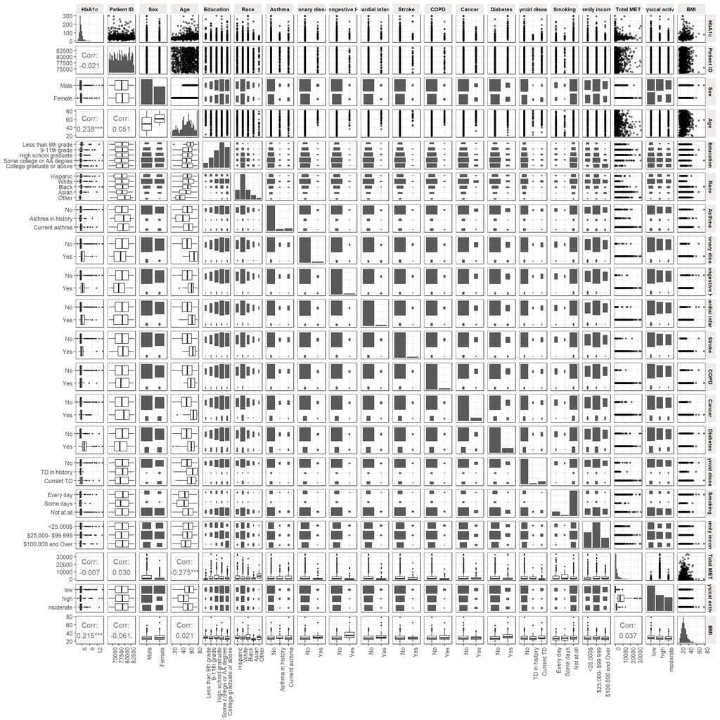

## 4. Оцените модель для зависимости гликированного гемоглобина от выбранного вами показателя физической активности без ковариат и с ними. Проведите необходимую диагностику этих моделей – требует ли что-либо коррекции и почему? В случае необходимости коррекции по результатам диагностики сделайте ее.

1. Оценим модель зависимости HbA1c от Physical activity **без ковариат**

```
##
## Call:
## lm(formula = HbA1c ~ `Physical activity`, data = cleaned_hw)
##
## Residuals:
##     Min      1Q  Median      3Q     Max
## -1.7014 -0.5014 -0.2014  0.1471  8.0112
##
## Coefficients:
##                             Estimate Std. Error t value Pr(>|t|)
## (Intercept)                  5.90142    0.05023 117.488  < 2e-16 ***
## `Physical activity`high     -0.21266    0.08069  -2.636  0.00854 **
## `Physical activity`moderate -0.14856    0.08493  -1.749  0.08060 .
## ---
## Signif. codes:  0 '***' 0.001 '**' 0.01 '*' 0.05 '.' 0.1 ' ' 1
##
## Residual standard error: 1.032 on 913 degrees of freedom
## Multiple R-squared:  0.008307,   Adjusted R-squared:  0.006134
## F-statistic: 3.824 on 2 and 913 DF,  p-value: 0.02219
```

Диагностика модели без ковариат:

Residuals vs Fitted

Вывод: график неинформативен для категориальной переменной.

Scale-Location

Вывод: дисперсия остатков разная и зависит от условного мат.ожидания.

Q-Q plot

Вывод: имеются отклонения распределения остатков от нормальности. Выбросы, некорректная спецификация формы зависимости? Так как выборка большая, можем ожидать соблюдение ЦПТ -> можем использовать квантили нормального распределения.

Residuals vs Leverage

Вывод: все расстояния Кука меньше 0.5. Влиятельные наблюдения отсутствуют.

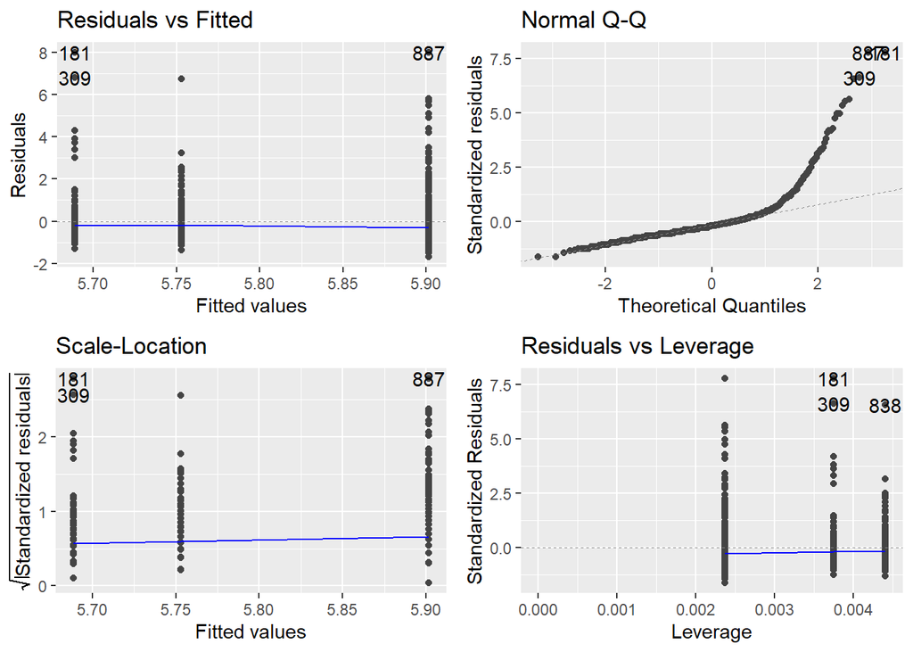

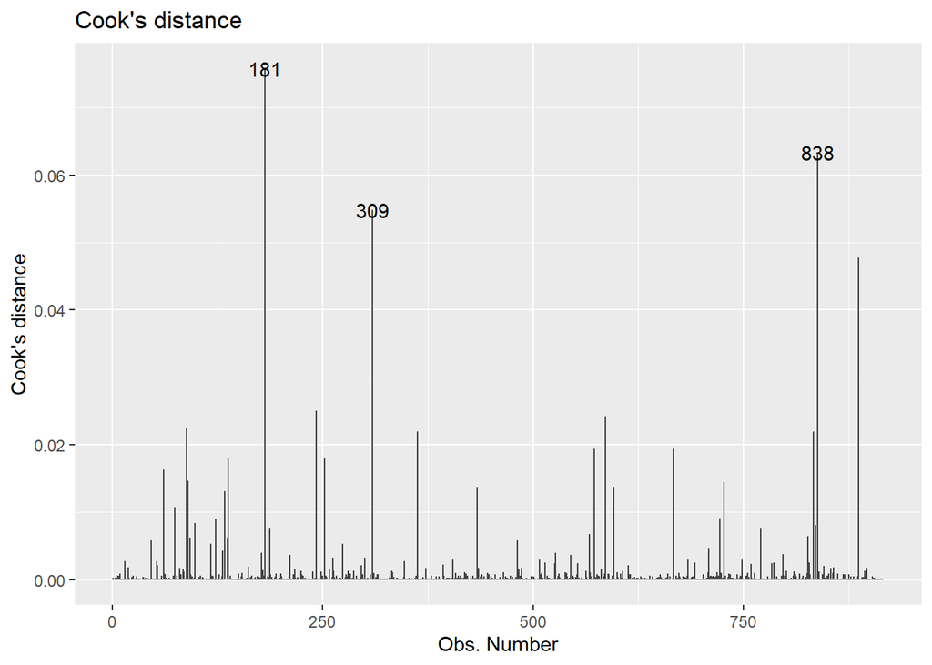

2. Оценим модель зависимости HbA1c от Physical activity **с ковариатами**

```
##
## Call:
## lm(formula = HbA1c ~ `Physical activity` + Sex + Age + Education +
##     Race + Asthma + `Coronary disease` + `Congestive HF` + `Myocardial infarction` +
##     Stroke + COPD + Cancer + Diabetes + `Thyroid disease` + Smoking +
##     `Family income`, data = cleaned_hw)
##
## Residuals:
##     Min      1Q  Median      3Q     Max
## -2.5654 -0.3328 -0.0568  0.2288  6.5305
##
## Coefficients:
##                                     Estimate Std. Error t value Pr(>|t|)
## (Intercept)                         5.450631   0.174968  31.152  < 2e-16 ***
## `Physical activity`high             0.078365   0.069173   1.133 0.257570
## `Physical activity`moderate        -0.083528   0.068005  -1.228 0.219679
## SexFemale                           0.050736   0.061572   0.824 0.410152
## Age                                 0.007008   0.002063   3.397 0.000712 ***
## Education9-11th grade              -0.179851   0.137140  -1.311 0.190050
## EducationHigh school graduate      -0.233637   0.131033  -1.783 0.074921 .
## EducationSome college or AA degree -0.212850   0.129737  -1.641 0.101229
## EducationCollege graduate or above -0.251319   0.136222  -1.845 0.065382 .
## RaceWhite                          -0.079439   0.078964  -1.006 0.314679
## RaceBlack                           0.201637   0.090395   2.231 0.025956 *
## RaceAsian                           0.102372   0.117710   0.870 0.384700
## RaceOther                          -0.125016   0.181747  -0.688 0.491721
## AsthmaAsthma in history            -0.076181   0.111056  -0.686 0.492908
## AsthmaCurrent asthma               -0.067792   0.096334  -0.704 0.481791
## `Coronary disease`Yes               0.382114   0.150076   2.546 0.011060 *
## `Congestive HF`Yes                  0.064793   0.164410   0.394 0.693606
## `Myocardial infarction`Yes         -0.015536   0.155619  -0.100 0.920499
## StrokeYes                           0.169432   0.149754   1.131 0.258191
## COPDYes                            -0.355748   0.144495  -2.462 0.014005 *
## CancerYes                          -0.046795   0.091190  -0.513 0.607970
## DiabetesYes                         1.609561   0.079673  20.202  < 2e-16 ***
## `Thyroid disease`TD in history     -0.358139   0.147299  -2.431 0.015238 *
## `Thyroid disease`Current TD        -0.059338   0.093432  -0.635 0.525531
## SmokingSome days                   -0.094743   0.162643  -0.583 0.560363
## SmokingNot at all                  -0.086774   0.081541  -1.064 0.287537
## `Family income`$25.000- $99.999    -0.018199   0.065477  -0.278 0.781121
## `Family income`$100,000 and Over    0.038360   0.090363   0.425 0.671296
## ---
## Signif. codes:  0 '***' 0.001 '**' 0.01 '*' 0.05 '.' 0.1 ' ' 1
##
## Residual standard error: 0.8079 on 888 degrees of freedom
## Multiple R-squared:  0.4088, Adjusted R-squared:  0.3908
## F-statistic: 22.74 on 27 and 888 DF,  p-value: < 2.2e-16
```

Диагностика модели с ковариатами:

Residuals vs Fitted

Scale-Location

Вывод: дисперсия остатков разная вдоль линии регрессии и зависит от условного мат.ожидания.

Q-Q plot

Вывод: имеются отклонения распределения остатков от нормальности. Выбросы, некорректная спецификация формы зависимости? Так как выборка большая, можем ожидать соблюдение ЦПТ -> можем использовать квантили нормального распределения.

Residuals vs Leverage

Вывод: все расстояния Кука меньше 0.5. Влиятельные наблюдения отсутствуют.

Мультиколлинеарность

Вывод: все коэффициенты VIF меньше 5 (не диагностирована мультиколлинеарность).

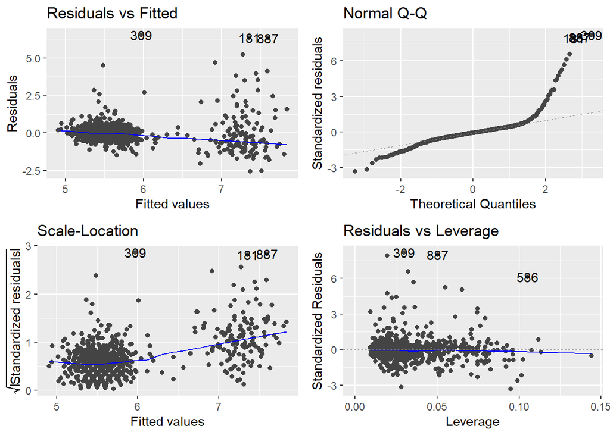

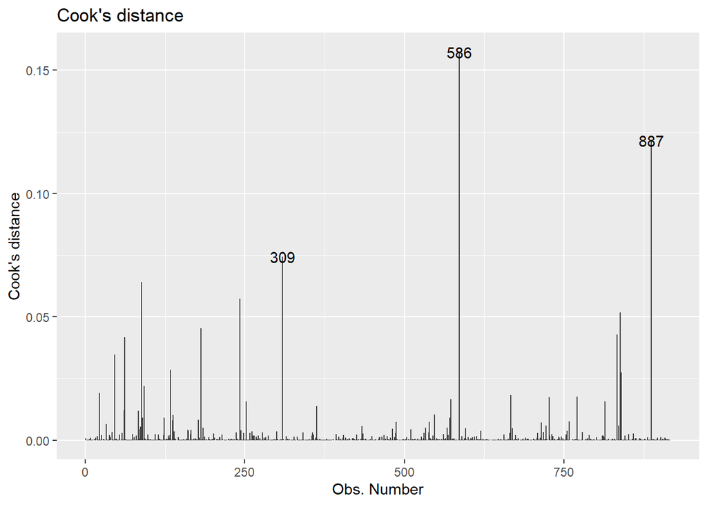

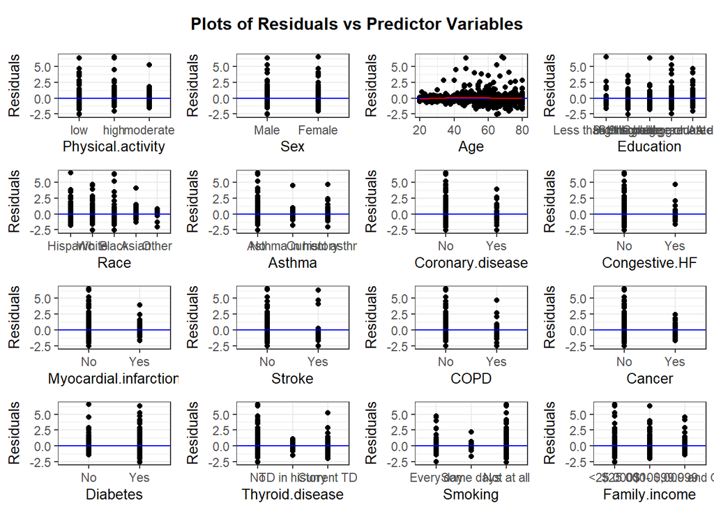

```
##                             GVIF Df GVIF^(1/(2*Df))
## `Physical activity`     1.246877  2        1.056710
## Sex                     1.288615  1        1.135172
## Age                     1.605260  1        1.266989
## Education               1.643618  4        1.064082
## Race                    1.483158  4        1.050506
## Asthma                  1.131531  2        1.031375
## `Coronary disease`      1.507723  1        1.227894
## `Congestive HF`         1.355899  1        1.164431
## `Myocardial infarction` 1.453255  1        1.205510
## Stroke                  1.061168  1        1.030130
## COPD                    1.194521  1        1.092941
## Cancer                  1.174656  1        1.083815
## Diabetes                1.180404  1        1.086464
## `Thyroid disease`       1.225533  2        1.052159
## Smoking                 1.182339  2        1.042763
## `Family income`         1.455824  2        1.098442
```

Коррекция модели

В данных имеются явные выбросы, однако их исключение нецелесообразно, так как это не случайные ошибки, а клинически возможные значения.

Проведем коррекцию стандартных ошибок на гетероскедастичность в модели без ковариат:

|  | term | estimate | std.error | statistic | p.value | conf.low | conf.high |
| --- | --- | --- | --- | --- | --- | --- | --- |
| 1 | (Intercept) | 5.901 | 0.056 | 106.162 | 0 | 5.792 | 6.011 |
| 2 | `Physical activity`high | -0.213 | 0.083 | -2.561 | 0.011 | -0.376 | -0.05 |
| 3 | `Physical activity`moderate | -0.149 | 0.078 | -1.906 | 0.057 | -0.302 | 0.004 |

Проведем коррекцию стандартных ошибок на гетероскедастичность в модели с ковариатами:

|  | term | estimate | std.error | statistic | p.value | conf.low | conf.high |
| --- | --- | --- | --- | --- | --- | --- | --- |
| 1 | (Intercept) | 5.451 | 0.186 | 29.344 | 0 | 5.086 | 5.815 |
| 2 | `Physical activity`high | 0.078 | 0.076 | 1.031 | 0.303 | -0.071 | 0.227 |
| 3 | `Physical activity`moderate | -0.084 | 0.06 | -1.396 | 0.163 | -0.201 | 0.034 |
| 4 | SexFemale | 0.051 | 0.066 | 0.773 | 0.44 | -0.078 | 0.18 |
| 5 | Age | 0.007 | 0.002 | 3.972 | 0 | 0.004 | 0.01 |
| 6 | Education9-11th grade | -0.18 | 0.183 | -0.983 | 0.326 | -0.539 | 0.179 |
| 7 | EducationHigh school graduate | -0.234 | 0.173 | -1.351 | 0.177 | -0.573 | 0.106 |
| 8 | EducationSome college or AA degree | -0.213 | 0.168 | -1.265 | 0.206 | -0.543 | 0.117 |
| 9 | EducationCollege graduate or above | -0.251 | 0.175 | -1.437 | 0.151 | -0.594 | 0.092 |
| 10 | RaceWhite | -0.079 | 0.07 | -1.135 | 0.257 | -0.217 | 0.058 |

[output cut: 18 more lines]

## 5. Представьте результаты оценки модели без ковариат и с ковариатами в виде точечной и интервальной оценки эффекта физической активности. Дайте им словесную интерпретацию. Какие выводы мы можем сделать, исходя из точечной оценки? А из интервальной? Как вы думаете, можно ли считать эффект клинически значимым? Если затрудняетесь с ответом, что бы вам помогло дать ответ на этот вопрос?

Оценка модели без ковариат:

Значение Intercept равно 5.90 (условное среднее значение HbAc1 при Physical activity = low)

В категории умеренной активности среднее HbAc1 ниже на 0.15% по сравнению с категорией низкой активности (p>0.05, 95% ДИ = [-0.30;0.004] - включает ноль). Результат статистически незначим.

В категории высокой активности среднее HbAc1 ниже на 0.21% по сравнению с категорией низкой активности (p<0.05, 95% ДИ = [-0.38;-0.05] - не включает ноль). Результат статистически значим.

Оценка модели с ковариатами:

При прочих равных и умеренной активности среднее HbA1c снижается на 0.08 (p>0.05, 95% ДИ = [-0.20;0.03]), при высокой активности и прочих равных повышается на 0.08 (p>0.05, 95% ДИ = [-0.07;0.23]). Клиническая значимость отсутствует.

Статистически значимыми будут следующие ковариаты:

- Возраст (увеличение на 0.007 с каждым годом, p<0.05, 95% ДИ = [0.0035;0.010])
- Наличие диабета (увеличение на 1.61, p<0.05, 95% ДИ = [1.33;1.89])
- Наличие заболеваний ЩЖ в анамнезе (снижение на 0.36, p<0.05, 95% ДИ = [-0.57;-0.15])

## 6. Проверьте гипотезу об отсутствии ассоциации между физической активностью и гликированным гемоглобином. Сделайте выводы по полученным результатам.

H0: beta(moderate) = beta(high) = 0

Ha: beta(moderate) != 0 и/или beta(high) != 0

В модели без ковариат:

p<0.05 (p = 0.028)

Вывод: Отвергаем нулевую гипотезу в пользу альтернативной. Существует статистически значимая разница между низкой активностью и минимум одной из категорий: умеренная и высокая активность.

```
##
## Linear hypothesis test:
## Physical activity`high = 0
## Physical activity`moderate = 0
##
## Model 1: restricted model
## Model 2: HbA1c ~ `Physical activity`
##
## Note: Coefficient covariance matrix supplied.
##
##   Res.Df Df      F  Pr(>F)
## 1    915
## 2    913  2 3.5821 0.02821 *
## ---
## Signif. codes:  0 '***' 0.001 '**' 0.01 '*' 0.05 '.' 0.1 ' ' 1
```

Для модели с ковариатами:

p>0.05 (p = 0.060)

Вывод: Не можем отвергнуть нулевую гипотезу. Отсутствует статистически значимая разница между низкой, умеренной и высокой активностью.

```
##
## Linear hypothesis test:
## Physical activity`high = 0
## Physical activity`moderate = 0
##
## Model 1: restricted model
## Model 2: HbA1c ~ `Physical activity` + Sex + Age + Education + Race +
##     Asthma + `Coronary disease` + `Congestive HF` + `Myocardial infarction` +
##     Stroke + COPD + Cancer + Diabetes + `Thyroid disease` + Smoking +
##     `Family income`
##
## Note: Coefficient covariance matrix supplied.
##
##   Res.Df Df      F  Pr(>F)
## 1    890
## 2    888  2 2.8209 0.06009 .
## ---
## Signif. codes:  0 '***' 0.001 '**' 0.01 '*' 0.05 '.' 0.1 ' ' 1
```

## 7. Является ли пол модификатором эффекта физической активности в отношении гликированного гемоглобина? Если да, каков эффект для мужчин и женщин и насколько он отличается между ними?

Включим пол в модель как модификатор.

Н0: beta(`Physical activity`high:SexFemale) = beta (`Physical activity`moderate:SexFemale) = 0

Ha: beta(`Physical activity`high:SexFemale) !=0 и/или beta (`Physical activity`moderate:SexFemale) != 0

Результат: p>0.05 (p = 0.875)

Не можем отвергнуть нулевую гипотезу. Нет различий между изменением уровня гликированного гемоглобина при умеренной и высокой физической активности по сравнению с низкой у женщин и аналогичным изменением у мужчин.

```
##
## Call:
## lm(formula = HbA1c ~ `Physical activity` * Sex + Age + Education +
##     Race + Asthma + `Coronary disease` + `Congestive HF` + `Myocardial infarction` +
##     Stroke + COPD + Cancer + Diabetes + `Thyroid disease` + Smoking +
##     `Family income`, data = cleaned_hw)
##
## Residuals:
##     Min      1Q  Median      3Q     Max
## -2.5512 -0.3358 -0.0537  0.2327  6.5440
##
## Coefficients:
##                                        Estimate Std. Error t value Pr(>|t|)
## (Intercept)                            5.432175   0.178873  30.369  < 2e-16 ***
## `Physical activity`high                0.097616   0.084694   1.153 0.249397
## `Physical activity`moderate           -0.052651   0.092296  -0.570 0.568510
## SexFemale                              0.078894   0.083547   0.944 0.345274
## Age                                    0.007042   0.002067   3.408 0.000685 ***
## Education9-11th grade                 -0.178672   0.137313  -1.301 0.193528
## EducationHigh school graduate         -0.232080   0.131247  -1.768 0.077360 .
## EducationSome college or AA degree    -0.212235   0.129922  -1.634 0.102707
## EducationCollege graduate or above    -0.249241   0.136424  -1.827 0.068043 .
## RaceWhite                             -0.081038   0.079103  -1.024 0.305893
## RaceBlack                              0.201567   0.090506   2.227 0.026191 *
## RaceAsian                              0.103071   0.117839   0.875 0.381989
## RaceOther                             -0.128964   0.182095  -0.708 0.478995
## AsthmaAsthma in history               -0.076243   0.111248  -0.685 0.493303
## AsthmaCurrent asthma                  -0.068631   0.096539  -0.711 0.477327
## `Coronary disease`Yes                  0.386265   0.150442   2.568 0.010406 *
## `Congestive HF`Yes                     0.070465   0.165074   0.427 0.669577
## `Myocardial infarction`Yes            -0.018630   0.155891  -0.120 0.904902
## StrokeYes                              0.164733   0.150180   1.097 0.272983
## COPDYes                               -0.353891   0.144694  -2.446 0.014647 *
## CancerYes                             -0.044383   0.091566  -0.485 0.628003
## DiabetesYes                            1.609090   0.079780  20.169  < 2e-16 ***
## `Thyroid disease`TD in history        -0.357636   0.147455  -2.425 0.015491 *
## `Thyroid disease`Current TD           -0.060303   0.093542  -0.645 0.519312
## SmokingSome days                      -0.093526   0.162876  -0.574 0.565966
## SmokingNot at all                     -0.085216   0.081751  -1.042 0.297518
## `Family income`$25.000- $99.999       -0.018689   0.065548  -0.285 0.775622
## `Family income`$100,000 and Over       0.039974   0.090594   0.441 0.659146
## `Physical activity`high:SexFemale     -0.046347   0.143837  -0.322 0.747364
## `Physical activity`moderate:SexFemale -0.066207   0.135490  -0.489 0.625214
## ---
## Signif. codes:  0 '***' 0.001 '**' 0.01 '*' 0.05 '.' 0.1 ' ' 1
##
## Residual standard error: 0.8087 on 886 degrees of freedom
## Multiple R-squared:  0.4089, Adjusted R-squared:  0.3896
## F-statistic: 21.14 on 29 and 886 DF,  p-value: < 2.2e-16
```

```
##
## Linear hypothesis test:
## Physical activity`high:SexFemale = 0
## Physical activity`moderate:SexFemale = 0
##
## Model 1: restricted model
## Model 2: HbA1c ~ `Physical activity` * Sex + Age + Education + Race +
##     Asthma + `Coronary disease` + `Congestive HF` + `Myocardial infarction` +
##     Stroke + COPD + Cancer + Diabetes + `Thyroid disease` + Smoking +
##     `Family income`
##
##   Res.Df    RSS Df Sum of Sq      F Pr(>F)
## 1    888 579.55
## 2    886 579.38  2   0.17414 0.1332 0.8754
```

## 8. Соответствуют ли полученные вами результаты вашему исходному предположению? Как меняется оценка эффекта физической активности при добавлении ковариат в модель и почему?

Изначальное предположение, что с увеличением физической активности уменьшается значение HbA1c, было подтверждено только в модели без ковариат. В модели с ковариатами статистически значимых различий между группами физической активности нет. Это может свидетельствовать о том, что другие факторы преимущественно объясняют различия в HbA1c.

• Бонусное задание: оцените прямой (direct) эффект физической активности на гликированный гемоглобин (со всей необходимой диагностикой и коррекциями). Как он отличается от общего (total) эффекта? В чем причина/ механизм этих различий?

```
##
## Call:
## lm(formula = HbA1c ~ `Physical activity` + Sex + Age + Education +
##     Race + Asthma + `Coronary disease` + `Congestive HF` + `Myocardial infarction` +
##     Stroke + COPD + Cancer + Diabetes + `Thyroid disease` + Smoking +
##     `Family income` + BMI, data = cleaned_hw)
##
## Residuals:
##     Min      1Q  Median      3Q     Max
## -2.6451 -0.3360 -0.0460  0.2278  6.5470
##
## Coefficients:
##                                     Estimate Std. Error t value Pr(>|t|)
## (Intercept)                         4.982267   0.215177  23.154  < 2e-16 ***
## `Physical activity`high             0.095230   0.068839   1.383 0.166897
## `Physical activity`moderate        -0.062922   0.067758  -0.929 0.353339
## SexFemale                           0.032707   0.061335   0.533 0.593994
## Age                                 0.007495   0.002053   3.651 0.000277 ***
## Education9-11th grade              -0.168652   0.136211  -1.238 0.215979
## EducationHigh school graduate      -0.237107   0.130116  -1.822 0.068749 .
## EducationSome college or AA degree -0.204851   0.128844  -1.590 0.112210
## EducationCollege graduate or above -0.231899   0.135367  -1.713 0.087041 .
## RaceWhite                          -0.075341   0.078417  -0.961 0.336928
## RaceBlack                           0.187140   0.089846   2.083 0.037547 *
## RaceAsian                           0.172824   0.118432   1.459 0.144848
## RaceOther                          -0.133861   0.180485  -0.742 0.458483
## AsthmaAsthma in history            -0.089820   0.110337  -0.814 0.415837
## AsthmaCurrent asthma               -0.074276   0.095673  -0.776 0.437749
## `Coronary disease`Yes               0.404175   0.149141   2.710 0.006858 **
## `Congestive HF`Yes                 -0.054724   0.166438  -0.329 0.742386
## `Myocardial infarction`Yes         -0.022872   0.154538  -0.148 0.882373
## StrokeYes                           0.204862   0.149012   1.375 0.169539
## COPDYes                            -0.359840   0.143484  -2.508 0.012323 *
## CancerYes                          -0.017881   0.090888  -0.197 0.844080
## DiabetesYes                         1.554161   0.080526  19.300  < 2e-16 ***
## `Thyroid disease`TD in history     -0.335960   0.146387  -2.295 0.021965 *
## `Thyroid disease`Current TD        -0.052104   0.092796  -0.561 0.574604
## SmokingSome days                   -0.103201   0.161516  -0.639 0.523018
## SmokingNot at all                  -0.122201   0.081535  -1.499 0.134294
## `Family income`$25.000- $99.999    -0.029979   0.065095  -0.461 0.645244
## `Family income`$100,000 and Over    0.034841   0.089733   0.388 0.697903
## BMI                                 0.015979   0.004331   3.689 0.000239 ***
## ---
## Signif. codes:  0 '***' 0.001 '**' 0.01 '*' 0.05 '.' 0.1 ' ' 1
##
## Residual standard error: 0.8022 on 887 degrees of freedom
## Multiple R-squared:  0.4177, Adjusted R-squared:  0.3993
## F-statistic: 22.72 on 28 and 887 DF,  p-value: < 2.2e-16
```

Диагностика модели прямого эффекта:

Residuals vs Fitted

Scale-Location

Вывод: дисперсия остатков разная вдоль линии регрессии и зависит от условного мат.ожидания.

Q-Q plot

Вывод: имеются отклонения распределения остатков от нормальности. Выбросы, некорректная спецификация формы зависимости?

Residuals vs Leverage

Вывод: все расстояния Кука меньше 0.5. Не обнаружено влиятельных значений.

Мультиколлинеарность

Вывод: все коэффициенты VIF меньше 5 (не диагностирована мультиколлинеарность).

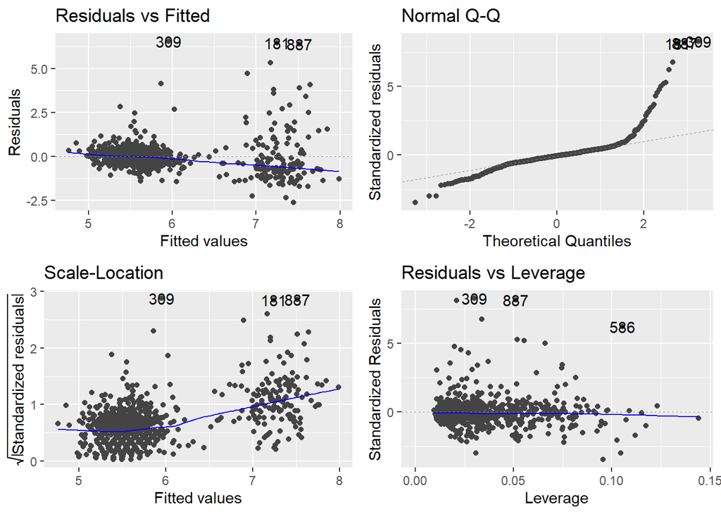

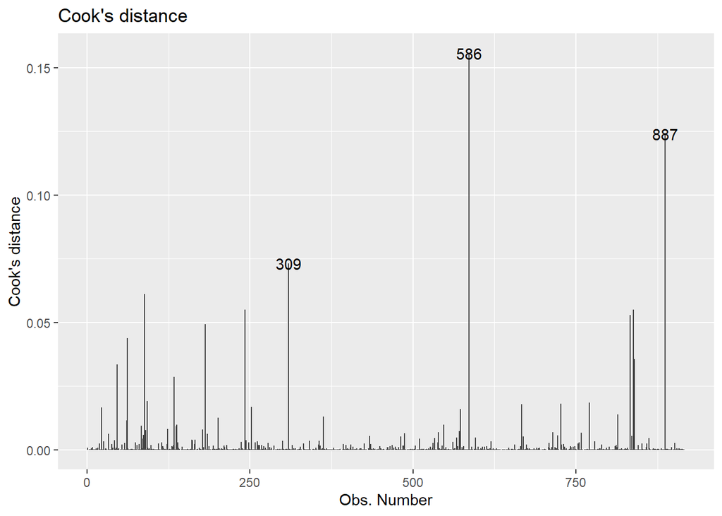

Проведем коррекцию стандартных ошибок на гетероскедастичность:

VIF < 5, мультиколлинеарность не выявлена.

```
##                             GVIF Df GVIF^(1/(2*Df))
## `Physical activity`     1.257241  2        1.058899
## Sex                     1.296848  1        1.138792
## Age                     1.611921  1        1.269615
## Education               1.653617  4        1.064889
## Race                    1.546678  4        1.056027
## Asthma                  1.133068  2        1.031725
## `Coronary disease`      1.510151  1        1.228882
## `Congestive HF`         1.409288  1        1.187134
## `Myocardial infarction` 1.453496  1        1.205610
## Stroke                  1.065593  1        1.032276
## COPD                    1.194592  1        1.092974
## Cancer                  1.183455  1        1.087867
## Diabetes                1.222929  1        1.105861
## `Thyroid disease`       1.227920  2        1.052671
## Smoking                 1.200432  2        1.046729
## `Family income`         1.459850  2        1.099201
## BMI                     1.208904  1        1.099502
```

Значение Intercept равно 4.98 (условное среднее значение HbAc1 при Physical activity = low, Sex = Male, Age = 0, Education = Less than 9th grade, Race = Hispanic, Smoking = Every day, Family income = <25.000, Comorbidities = No, BMI=0)

При прочих равных и умеренной активности HbA1c снижается на 0.06 (p>0.05, 95% ДИ = [-0.18;0.05]), при высокой активности и прочих равных повышается на 0.10 (p>0.05, 95% ДИ = [-0.05;0.24])

Статистически значимыми будут следующие ковариаты:

-ИМТ (увеличение на 0.02 при прибавке каждой единицы, p<0.05, 95% ДИ = [0.006;0.025])

|  | term | estimate | std.error | statistic | p.value | conf.low | conf.high |
| --- | --- | --- | --- | --- | --- | --- | --- |
| 1 | (Intercept) | 4.982 | 0.226 | 22.029 | 0 | 4.538 | 5.426 |
| 2 | `Physical activity`high | 0.095 | 0.076 | 1.256 | 0.21 | -0.054 | 0.244 |
| 3 | `Physical activity`moderate | -0.063 | 0.059 | -1.058 | 0.29 | -0.18 | 0.054 |
| 4 | SexFemale | 0.033 | 0.065 | 0.506 | 0.613 | -0.094 | 0.16 |
| 5 | Age | 0.007 | 0.002 | 4.318 | 0 | 0.004 | 0.011 |
| 6 | Education9-11th grade | -0.169 | 0.181 | -0.93 | 0.353 | -0.525 | 0.187 |
| 7 | EducationHigh school graduate | -0.237 | 0.171 | -1.388 | 0.165 | -0.572 | 0.098 |
| 8 | EducationSome college or AA degree | -0.205 | 0.166 | -1.235 | 0.217 | -0.53 | 0.121 |
| 9 | EducationCollege graduate or above | -0.232 | 0.173 | -1.342 | 0.18 | -0.571 | 0.107 |
| 10 | RaceWhite | -0.075 | 0.069 | -1.089 | 0.276 | -0.211 | 0.06 |

[output cut: 19 more lines]

Вывод: В модели с ковариатами и общий, и прямой эффекты без учета ИМТ одинаковы по направленности: снижение гликированного гемоглобина при умеренной активности по сравнению с низкой, и повышение при высокой, оба статистически незначимы при включении ковариат. Следовательно, эффекта физической активности на гликированный гемоглобин не обнаружено. Увеличение ИМТ на каждую единицу статистически значимо увеличивает HbA1c на 0.02%, что также может быть клинически значимо (в частности, при сравнении нормального ИМТ и ожирения).